# PSTAT 131 HW1

## Exercise 4

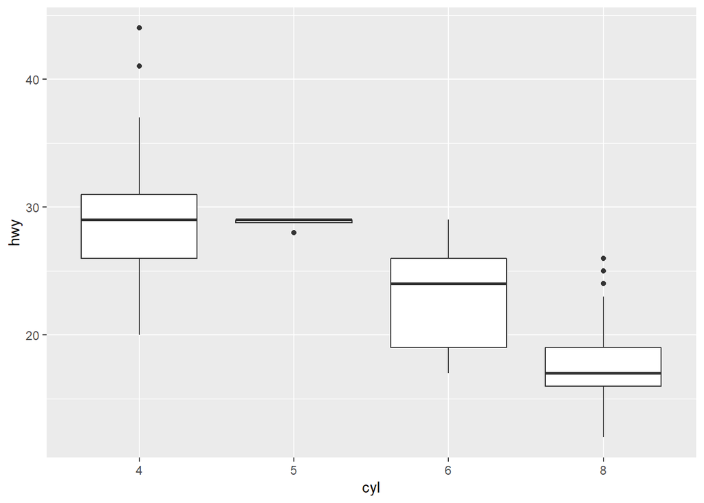

```r
mpg$cyl <- as.factor(mpg$cyl) #Changing to factor variable for grouping
ggplot(mpg, aes(x=cyl, y=hwy)) + geom_boxplot()
```

It seems that as the number of cylinders increases, mpg decreases.

## Exercise 5

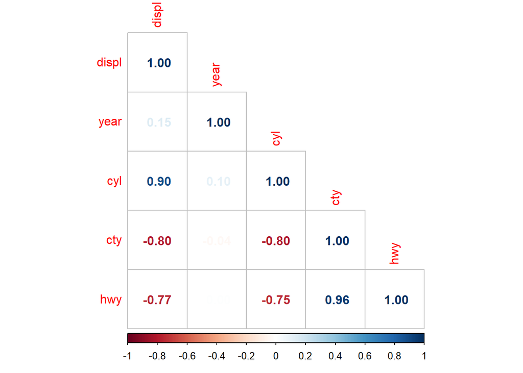

```r
#Changing cylinder back to numeric variable
mpg$cyl <- as.numeric(mpg$cyl)
#Dropping non-numeric variables
df <- subset(mpg, select = -c(manufacturer, model, trans, drv, fl, class))

m1 = cor(df)

corrplot(m1, method = "number", type = "lower")
```

Engine displacement and number of cylinders are positively correlated but that’s because number of cylinders is actually factored into the formula to calculate engine displacement.

Engine displacement is also negatively correlated with mileage, likely because a bigger engine is positively correlated with larger vehicles and more powerful engines, both of which are less efficient in terms of mileage.

Similarly the number of cylinders is also negatively correlated with mileage because cyl is positively correlated with engine displacement, which makes sense as noted above.

The overall trend for the whole correlation matrix seems to be that larger engines correlate with lower mileage.